# What is SNAP? Is it helpful?

```r
r1="Northeast"
r2="Midwest"
r3="South"
r4="West"

s1<-c("Connecticut", "Maine", "Massachusetts", "New Hampshire", "Rhode Island", "Vermont", "New Jersey", "New York","Pennsylvania")
s2<-c("Illinois", "Indiana", "Michigan", "Ohio", "Wisconsin", "Iowa", "Kansas", "Minnesota", "Missouri", "Nebraska", "North Dakota", "South Dakota")
s3<-c("Delaware", "Florida", "Georgia", "Maryland", "North Carolina", "South Carolina", "Virginia", "District of Columbia", "Alabama", "Kentucky", "Mississippi", "Tennessee", "Arkansas", "Louisiana", "Oklahoma", "Texas")
s4<-c("Arizona", "Colorado", "Idaho", "Montana", "Nevada", "New Mexico", "Utah", "Wyoming","Alaska", "California", "Hawaii", "Oregon", "Washington")


for (row in 1:nrow(part_18)) {
  state <- part_18[row, "state"]
  if (state %in% s1) {
  region = r1
}else if(state %in% s2){
  region = r2
}else if(state %in% s3){
  region = r3
}else if(state %in% s4) {
  region = r4
}
  part_18$region[row] <- region}
```

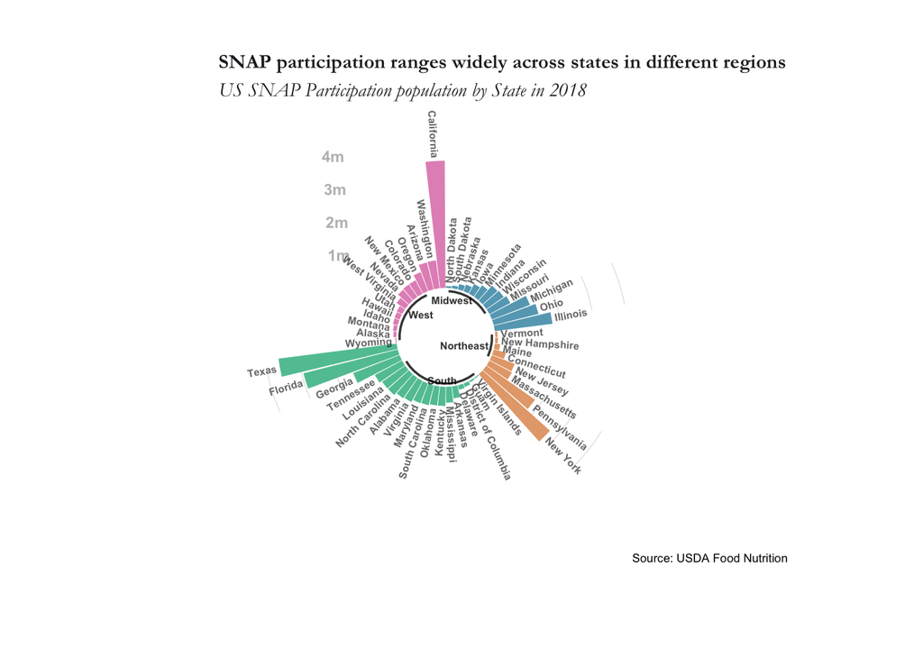

```r
data = data %>% arrange(region, as.numeric(as.character(sep18)))

# Set a number of 'empty bar' to add at the end of each group
empty_bar=3
to_add = data.frame( matrix(NA, empty_bar*nlevels(data$region), ncol(data)) )
colnames(to_add) = colnames(data)
to_add$group=rep(levels(data$region), each=empty_bar)
data=rbind(data, to_add)
data=data %>% arrange(region)
data$id=seq(1, nrow(data))


# Get the name and the y position of each label
label_data=data
number_of_bar=nrow(label_data)
angle= 90 - 360 * (label_data$id-0.5) /number_of_bar     # I substract 0.5 because the letter must have the angle of the center of the bars. Not extreme right(1) or extreme left (0)
label_data$hjust<-ifelse( angle < -90, 1, 0)
label_data$angle<-ifelse(angle < -90, angle+180, angle)

# prepare a data frame for base lines
base_data=data %>%
  group_by(region) %>%
  summarize(start=min(id), end=max(id) - empty_bar) %>%
  rowwise() %>%
  mutate(title=mean(c(start, end)))


# prepare a data frame for grid (scales)
grid_data = base_data
grid_data$end = grid_data$end[ c( nrow(grid_data), 1:nrow(grid_data)-1)] + 1
grid_data$start = grid_data$start - 1
grid_data=grid_data[-1,]

colors_in = c("#2188a8","#dd8944","#11af80","#db6bac")

# Make the plot
p = ggplot(data, aes(x=as.factor(id), y=as.numeric(as.character(sep18)), fill=region))+ scale_fill_manual(values=colors_in)+       # Note that id is a factor. If x is numeric, there is some space between the first bar

  geom_bar(aes(x=as.factor(id), y=as.numeric(as.character(sep18)), fill=region), stat="identity", alpha=0.5) +

  # Add a val=100/75/50/25 lines. I do it at the beginning to make sur barplots are OVER it.
  geom_segment(data=grid_data, aes(x = end, y = 4000000, xend = start, yend = 4000000), colour = "grey", alpha=1, size=0.1 , inherit.aes = FALSE ) +
  geom_segment(data=grid_data, aes(x = end, y = 3000000, xend = start, yend = 3000000), colour = "grey", alpha=1, size=0.1 , inherit.aes = FALSE ) +
  geom_segment(data=grid_data, aes(x = end, y = 2000000, xend = start, yend = 2000000), colour = "grey", alpha=1, size=0.1 , inherit.aes = FALSE ) +
  geom_segment(data=grid_data, aes(x = end, y = 1000000, xend = start, yend = 1000000), colour = "grey", alpha=1, size=0.1 , inherit.aes = FALSE ) +

  # Add text showing the value of each 100/75/50/25 lines
  annotate("text", x = rep(max(data$id),4), y = c(1000000, 2000000, 3000000, 4000000), label = c("1m", "2m", "3m", "4m") , color="grey", size=3 , angle=0, fontface="bold", hjust=5) +
  geom_bar(aes(x=as.factor(id), y=as.numeric(as.character(sep18)), fill=region), stat="identity", alpha=0.5) +
  ylim(-1500000,4000000) +
theme_minimal() +
theme(plot.title = element_text(size = 11,face = "bold",
                                  family = "Garamond",
                              lineheight = 0.5,
                                   color = textcolor),
       plot.subtitle = element_text(size = 11,
                                  family = "Garamond",face = "italic",
                              lineheight = 0.5,
                                   color = textcolor),
        plot.caption = element_text(size = 6,
                                  family = "Arial",
                              lineheight = 0.5,
                                   color = textcolor),
                              legend.position = "none",
      axis.text = element_blank(),
   axis.title = element_blank(),
   panel.grid = element_blank(), plot.margin = margin(t = 30,
                                       r = 30,
                                       b = 30,
                                       l = 10,
                                    unit = "pt"))+

  coord_polar()+
  geom_text(data=label_data, aes(x=id, y=as.numeric(as.character(sep18))+100000, label=state, hjust=hjust), color="black", fontface="bold",alpha=0.6, size=2, angle= label_data$angle, inherit.aes = FALSE ) +
  # Add base line information
  geom_segment(data=base_data, aes(x = start, y =-100000, xend = end, yend = -100000), colour = "black", alpha=0.8, size=0.6, inherit.aes = FALSE )  +
  geom_text(data=base_data, aes(x = title, y = -180000, label=region), hjust=c(0.9,1,0.35,0), colour = "black", alpha=0.8, size=2, fontface="bold", inherit.aes = FALSE)+
  labs(title="SNAP participation ranges widely across states in different regions", subtitle="US SNAP Participation population by State in 2018" )

p3<-add_sub(p, "Source: USDA Food Nutrition", y  = 0, hjust=-1.2,vjust = -5,size=6.5)
ggdraw(p3)
```

```r
# annotate("text",x=-Inf,y=-Inf,hjust=5,vjust=0,label="Source: USDA Food Nutrition")
# caption = "Source: USDA Food Nutrition Services\nhttps://www.fns.usda.gov/pd/supplemental-nutrition-assistance-program-snap"
```

Participation population of SNAP program in US across the 51 states, four regions, are shown above. West has the widest range of participation numbers, while the it’s more concentrated for Midwest. Overall, at state level, California has the most participations, nearly 4 million, and Wyoming has the fewest participants, about 0.1 million.

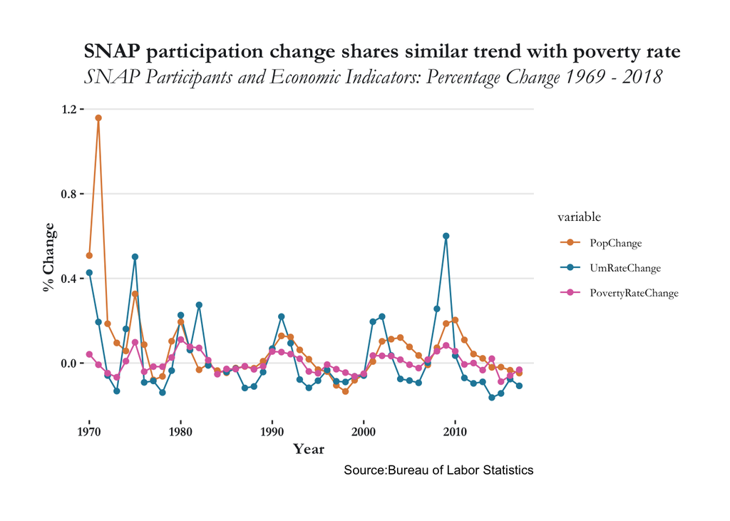

```r
library(reshape2)
meltdf <- melt(time.series,id="Year")

ggplot(meltdf,aes(x=Year,y=as.numeric(value),colour=variable,group=variable)) + ylab("% Change") + geom_line() +geom_point() +
  labs(title = "SNAP participation change shares similar trend with poverty rate",
        subtitle = "SNAP Participants and Economic Indicators: Percentage Change 1969 - 2018",
         caption = "Source:Bureau of Labor Statistics"
    ) +
  scale_color_manual(values = c("#dd8944","#2188a8","#db6bac"))+scale_x_discrete(breaks =c(1970,1980,1990,2000,2010,2020)) +
scale_y_continuous(limits=c(-.2,1.2)) +
  custom_theme
```

Overall, the changes of SNAP participation population, unemployment rate, and poverty rate have similar trends. Unemployment rate change fluctuates more than the other two rates, while the poverty rate change is the most consistent over the years. One outlier is in 1971, the SNAP population doubled compared to the previous year and then came back.

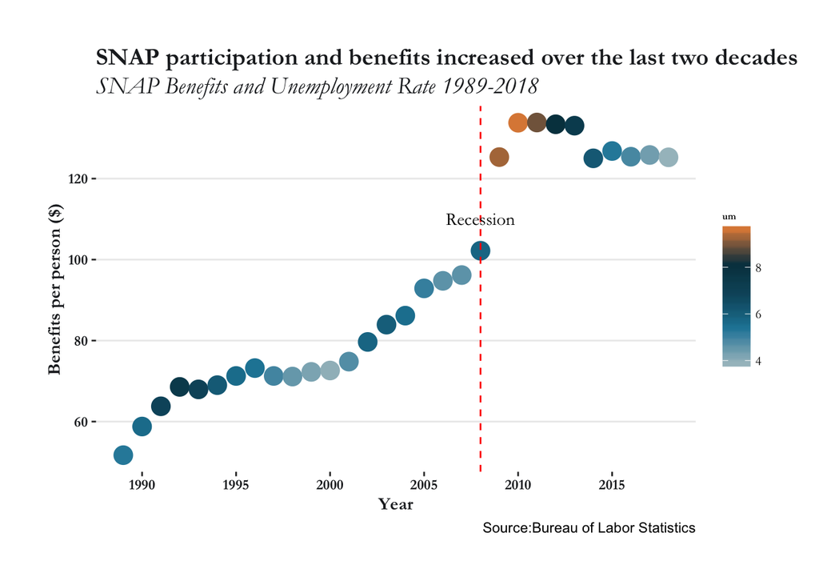

```r
um<-read.xlsx("um_79to18.xlsx",header=TRUE,sheetIndex = 1)[11:40,]
part_ben$um<-um$Unemployment.Rate

b <- ggplot(part_ben, aes(x = Year, y=Benefit.dollar.person.))

b + geom_point(aes(colour = um), size = 5)+ scale_color_gradientn(colours = c("#a5bfc6","#2188a8","#0c566d","#033d4c","#dd8944"))+ scale_x_continuous(breaks =c(1990,1995,2000,2005,2010,2015))+

  #scale_fill_gradientn(colours = c("#a5bfc6","#2188a8","#0c566d","#033d4c","#dd8944"), breaks=c(4,6,8,10))+

  geom_vline(xintercept = 2008, color = "red", linetype = "dashed") +
  annotate("text", label = "Recession", x = 2008, y = 110, family="Garamond",color = "black")+ labs(y = "Benefits per person ($)",x = "Year",subtitle="SNAP Benefits and Unemployment Rate 1989-2018", title="SNAP participation and benefits increased over the last two decades",caption="Source:Bureau of Labor Statistics") +custom_theme+theme(
            legend.text = element_text(size = 8),
 legend.title=element_text(size=6,face="bold"))
```